# HPC for AI - Part 2

Fine-tuning and using a large language model on Isambard-AI

Author

Jean Golding Institute

[figure not shown]

# Introduction

In this course you’ll use Isambard-AI, one of the UK’s national supercomputers for AI research, to work with a large language model (LLM).

You will fine-tune Mistral 7B so that it learns to follow instructions, then call it from a program to label about 30,000 UK news headlines. An optional final section shows how to profile each step with Nsight Systems, to see how the GPU spends its time.

Fine-tune a language model on one GPU, then use it to do useful research work

Each section of the course starts with a question, and you’ll answer it by running part of a notebook on Isambard-AI:

Set up → Fine-tuning? → Base model → LoRA and QLoRA → Did it work? → vLLM → Prompting → Headlines → Wrap up → Profiling (optional)

### How to get the most out of this course

The notebook is already written, so you won’t need to type much code. Read each cell before you run it and make sure you know what it’s doing. Work through the sections in order, in the one notebook, because later sections use models and variables from earlier ones. Sections marked **stretch goal** are extras for when you finish early or come back afterwards. Training takes about 8 minutes, which is a good moment to ask questions.

### Intended learning outcomes

By the end of this course, you should be able to:

- Explain the difference between training, fine-tuning and retrieval (RAG), and choose between them.
- Fine-tune a language model with LoRA or QLoRA, and justify the choice from measurements.
- Run a model over thousands of inputs in one batch, and check and retry its answers.
- State the limits of labels produced by a language model.
- Work considerately on a shared supercomputer.
- Optionally, record an Nsight profile of a running job and use it to explain why a job is slow.

### Audience level

This is an intermediate course for researchers who can program in Python and want to use language models in their work. You should be comfortable with:

- Python, Jupyter and pandas: [Introduction to Data Analysis in Python](https://bristol-training.github.io/data-analysis-python-2/).
- What a neural network and its training loop are: [Introduction to AI](https://bristol-training.github.io/intro-to-ai/). That course stops short of HPC and language models, and this one picks up from there.
- Running commands in a terminal: [Introduction to the Command Line](https://bristol-training.github.io/intro-cli/).

[HPC for AI - Part 1](https://bristol-training.github.io/hpc-for-ai-1/) introduces Isambard-AI and JupyterHub, and is useful but not required.

### What this course doesn’t cover

Training a model from scratch, building a RAG system, multi-GPU training and running a model as a production service.

## How to read this document

Code from the course notebook is shown in a grey box with the notebook’s name at the top. You’ll find exactly the same code in one of the notebook’s cells:

```
hpc-for-ai-2.ipynb
```

```python
def free_gpu():
    gc.collect()
    torch.cuda.empty_cache()
```

Commands to type into a terminal look like this:

```
Terminal
```

```bash
nvidia-smi
```

There’s an exercise at the end of most sections, shown in a blue box. The answer is in the yellow box underneath; have a go yourself before you open it.

**NoteExercise**

This is an exercise. Click on the box below to see the answer.

**CautionAnswer (click to open)**

This is the answer.

Green boxes like this one sum up the main points of each section:

**TipKey points**

These are the main points to take away.

**ImportantInstructor notes**

Red boxes like this one are **instructor notes**. They are removed from the attendee copy of these notes (see `README.md`).

**How the session runs:** attendees run a complete notebook (`notebooks/hpc-for-ai-2.ipynb`) in JupyterHub on Isambard-AI, one GPU each. Introduce each section with the slides, then run the matching cells on your screen while attendees run them in their own session. Split the room in half, one half using `MODE = "qlora"` and the other `MODE = "lora"`, so that the whole group can compare the two in section 4 without anyone training twice.

**Suggested timings (2 hours):**

| Section | Topic | Approx. time |
| --- | --- | --- |
| 1 | Setup | 0:00–0:05 |
| 2 | What is fine-tuning? | 0:05–0:15 |
| 3 | What can the base model do? | 0:15–0:20 |
| 4 | Training with LoRA and QLoRA | 0:20–0:50 |
| 5 | Did it work? | 0:50–1:00 |
| 6 | Faster inference with vLLM (start vLLM) | 1:00–1:05 |
|  | Break | 1:05–1:20 |
| 6 | Faster inference with vLLM (continued) | 1:20–1:25 |
| 7 | Prompting from a program | 1:25–1:35 |
| 8 | A research question | 1:35–1:50 |
| 9 | Wrapping up and good practice | 1:50–2:00 |
| 10 | Optional: profiling | not timed |

Start the vLLM cell just before the break: it takes a minute or two the first time. If you’re short of time, skip running the reviews demo in section 7, but do run the cells that define `run`, `clean` and `run_checked`.

Before the course, work through the instructor setup at the end of these notes.

## Before the course

You’ll need:

- An Isambard-AI account that has been added to the course project. We’ll email you an invitation before the course; accept it and follow the steps in the email.
- A UNIX username, set in the BriCS portal. JupyterHub won’t start without one. There are instructions in [Setting your UNIX username](https://docs.isambard.ac.uk/user-documentation/guides/shortname/).
- A web browser. Everything happens in the browser, so you don’t need to install anything.

If you can, please check that you can log in to the [BriCS portal](https://portal.isambard.ac.uk) before the day.

# 1 Setup

How do I get a GPU with the model and data ready?

This course needs a GPU with plenty of memory, so unlike most Jean Golding Institute courses it won’t run on a laptop. It runs on Isambard-AI, with everything already downloaded. Nothing needs a Hugging Face login.

[figure not shown]

What happens when you start a JupyterHub session

## 1.1 Start a session

1. Go to https://apps.isambard.ac.uk/aip2-jupyter and log in.
2. Fill in the Server Options form:

| Field | What to choose |
| --- | --- |
| Project | The course project (we’ll tell you its name) |
| Job duration | The shortest option that lasts until the end of the course |
| Number of GH200s | 1 |
| Partition | Leave this empty |
| Reservation | `interactive` |

3. Click **Start**. You might see “Pending in queue” while Slurm finds you a node.
4. JupyterLab opens in your browser once the node is ready.

**WarningYour session has a time limit**

When the time you chose runs out, the session ends straight away, with no warning. Save your notebook regularly (*Ctrl+S* or *Cmd+S*).

## 1.2 Set up the course kernel

The *kernel* is the Python environment your notebook runs in. We’ve made one especially for this course, with PyTorch, Transformers, TRL, PEFT and vLLM installed. You only have to install it once.

1. **Install the course kernel.** Open a terminal (*File → New → Terminal*) and run the command below, then reload the browser page.

   ```
   Terminal
   ```

   ```bash
   bash $PROJECTDIR/hpc-for-ai-2/data/kernels/install-kernels.sh
   ```

2. **Work on your own copy of the notebook.** If everyone saves the shared one, each save overwrites someone else’s.

   ```
   Terminal
   ```

   ```bash
   cp $PROJECTDIR/hpc-for-ai-2/notebooks/hpc-for-ai-2.ipynb ~/
   ```

3. **Check the kernel name** at the top right of the notebook says **Fine-tuning + Nsight**. Any other kernel gives errors such as `No module named 'datasets'`.
4. **Run one notebook at a time on this kernel.** Only the first one you open can be profiled in the optional section 10. Any others still run, but `nsys` can’t record them.

## 1.3 Where things live

| What | Where |
| --- | --- |
| Your results and profiles | `WORK_PATH`, which is `$PROJECTDIR/$USER/llm-fine-tuning` |
| Model | Shared cache, `$PROJECTDIR/hpc-for-ai-2/data/hf-cache` |
| Datasets | `$PROJECTDIR/hpc-for-ai-2/data/alpaca` and `$PROJECTDIR/hpc-for-ai-2/data/headlines` |
| A trained adapter and example profiles, in case you fall behind | `$PROJECTDIR/hpc-for-ai-2/data/fallback` |

The model and datasets were downloaded before the course, so nobody has to download 28 GB on the day, and the kernel only reads the shared copy. You can read the shared folder but not change it.

## 1.4 Choose how to train

Choose how to train: `MODE = "qlora"` or `MODE = "lora"`. Section 4 explains the difference. In a taught session, you’ll be told which to use.

```
hpc-for-ai-2.ipynb
```

```python
import gc, glob, json, os, random, time

import matplotlib.pyplot as plt
import pandas as pd
import torch
from datasets import load_dataset
from peft import LoraConfig, PeftModel
from transformers import AutoModelForCausalLM, AutoTokenizer, BitsAndBytesConfig, TextStreamer
from trl import SFTConfig, SFTTrainer

MODE = "qlora"  # "qlora" or "lora"
MODEL_ID = "mistralai/Mistral-7B-v0.3"
PROJECTDIR = os.environ["PROJECTDIR"]
DATA = f"{PROJECTDIR}/hpc-for-ai-2/data"
WORK_PATH = os.environ["WORK_PATH"]
OUTPUT_DIR = f"{WORK_PATH}/sft-output/{MODE}"
os.makedirs(OUTPUT_DIR, exist_ok=True)
```

`free_gpu()` returns memory to the GPU after a model is deleted. We use it each time one model makes way for the next.

```
hpc-for-ai-2.ipynb
```

```python
def free_gpu():
    gc.collect()
    torch.cuda.empty_cache()
```

**TipKey points**

- JupyterHub asks the Slurm scheduler for a GPU and opens JupyterLab on a compute node.
- Install the course kernel once, and work on your own copy of the notebook.
- The model and data are shared and read-only; your results go in your own `WORK_PATH`.

**ImportantInstructor notes**

**Recommended time:** 5 minutes. **Demo this on screen**, slowly. Tell each half of the room which `MODE` to use.

**Common problems:**

- *No UNIX username set*: the session won’t start. Send them to the BriCS portal to set one; it can take a few minutes to work.
- *Not in the project*: the project won’t appear in the drop-down list. Check they’ve accepted the invitation.
- *Someone has filled in Partition*: ask them to stop the server and start again with Partition empty.
- *“Pending in queue” for a long time*: each person can only have one interactive job at a time. Check with `squeue --me --partition=interactive`, and `scancel` any old job.
- *Kernel not in the list*: reload the browser page after running `install-kernels.sh`.
- *`No module named 'datasets'`*: the notebook is on the wrong kernel. Choose **Fine-tuning + Nsight** from the kernel menu.
- *`KeyError: 'PROJECTDIR'`, or files not found under `$PROJECTDIR`*: `$PROJECTDIR` is set from each person’s default project. Check `echo $PROJECTDIR` in a terminal prints the course project’s folder. If it doesn’t, check which project they chose when starting the session.

**NoteExercise**

1. In a terminal, run `echo $PROJECTDIR`. Which folder does it print?
2. Run `nvidia-smi`. How much memory does your GPU have?
3. Check the kernel name in the top right of the notebook.

**CautionAnswer**

1. The course project’s folder. The shared course files are in `$PROJECTDIR/hpc-for-ai-2`, and yours go in `$PROJECTDIR/$USER`.
2. One GH200, with about 96 GB of memory (`nvidia-smi` shows it in MiB).
3. **Fine-tuning + Nsight**. Any other kernel gives errors such as `No module named 'datasets'`.

# 2 What is fine-tuning?

What does a base model do, and what will fine-tuning change?

## 2.1 What a language model does

A language model is a neural network like the ones in Introduction to AI, trained in the same way, but far larger and with a Transformer architecture. Mistral 7B has 7.3 billion parameters.

Text goes in as **tokens**, which are whole words or pieces of words, each with a number. The model outputs a probability for every possible next token. To generate text, a program picks a token, adds it to the input and runs the model again, one token at a time.

A base model is trained only to continue text in the way the text it has read tends to continue. It hasn’t been trained to answer questions, and fine-tuning will change that.

## 2.2 What fine-tuning is

**Fine-tuning** starts from a model that has already learned something general, and trains it a little further on a smaller, specific dataset. It needs far less data and compute than starting from nothing, because the model keeps most of what it already knows.

The idea is not specific to language models. Two examples:

|  | Starts from | Learns | What it shows |
| --- | --- | --- | --- |
| **This notebook** | Mistral 7B, trained only to predict the next word | Alpaca’s instruction and response format, from 3,200 examples | Behaviour changes visibly while training under 1% of the parameters |
| **[Forest-Chat](https://arxiv.org/abs/2601.14637)** (Brock, Zhang and Anantrasirichai, University of Bristol, 2026) | A forest-change detection model pretrained on the Forest-Change dataset | Change detection on woodland images from a different source, JL1-CD-Trees (408 samples) | Fine-tuning on 5–10% of the new data lifts accuracy well above using a model with no training on it. With all the new data, training from scratch sometimes does as well or better |

## 2.3 Training, fine-tuning or RAG?

**Retrieval-augmented generation (RAG)** doesn’t change the model at all. It searches your documents for text relevant to a question and adds that text to the prompt, so the model can answer from it.

|  | Training from scratch | Fine-tuning | RAG |
| --- | --- | --- | --- |
| What changes | All the weights, starting from random | Some or all of the weights of a trained model | No weights: relevant text is added to the prompt |
| Data needed | Vast | Hundreds to thousands of labelled examples | Your documents, no labels |
| Compute | A very large cluster | One GPU, for minutes to hours | Mostly at question time, plus building a search index |
| Good for | Creating new foundation models | A format, style or narrow skill | Facts the model doesn’t have, or that change |
| Weakness | Cost | Fixed once trained, and doesn’t reliably add facts | Only as good as what it retrieves |

Choose in this order:

1. **Try prompting first.** If a good instruction gets you what you need, you don’t need to train anything.
2. **Use RAG** if the model needs facts it doesn’t have.
3. **Fine-tune** if you need a consistent format, style or narrow skill, and you have labelled examples.
4. **Train from scratch** only rarely, because few research groups have the data or the compute.

## 2.4 Dataset

Stanford Alpaca has about 52,000 instruction-following examples. Each is already a single `text` field in one fixed layout: an instruction, then `### Response:`, then the answer. This layout is what the model learns to complete.

Alpaca is for non-commercial use, so check the licence before reusing it. This copy was saved to the shared course data before the session. (Online, it loads with `load_dataset("tatsu-lab/alpaca", split="train")`.)

```
hpc-for-ai-2.ipynb
```

```python
dataset = load_dataset("parquet", data_files=f"{DATA}/alpaca/train.parquet", split="train")

print(len(dataset), "examples")
print(dataset[0]["text"])
```

**TipKey points**

- Fine-tuning trains an existing model a little further on a small, specific dataset.
- Try prompting first, use RAG for missing facts, and fine-tune for a format, style or narrow skill.

**ImportantInstructor notes**

**Recommended time:** 10 minutes. Talk through the training, fine-tuning and RAG table, and ask the room which they would use for a problem in their own work.

# 3 What can the base model do?

What does the model do before any fine-tuning?

Before training anything, see what the model does on its own. It has read a vast amount of text, but it was only ever trained to predict the next word. It has never been taught to answer.

The model reads and writes tokens, not text: its tokenizer converts between the two. Training puts texts of different lengths into one batch and pads the short ones, and Mistral has no padding token of its own, so we reuse its end-of-text token.

Give it the start of a sentence. What comes back is a plausible continuation, which is not necessarily the fact you were hoping for. `TextStreamer` prints each word as soon as the model produces it, so you can watch the answer being written.

```
hpc-for-ai-2.ipynb
```

```python
tokenizer = AutoTokenizer.from_pretrained(MODEL_ID)
tokenizer.pad_token = tokenizer.eos_token  # Mistral has no padding token
base_model = AutoModelForCausalLM.from_pretrained(MODEL_ID, dtype=torch.bfloat16, device_map="cuda")
streamer = TextStreamer(tokenizer, skip_prompt=True, skip_special_tokens=True)  # print words as they come

inputs = tokenizer("The capital of France is", return_tensors="pt").to(base_model.device)
output = base_model.generate(**inputs, max_new_tokens=40, do_sample=False, streamer=streamer,
                             pad_token_id=tokenizer.eos_token_id)
```

Now ask a direct question. A base model often treats a question as the start of a document rather than something to answer, so it may write more questions or repeat itself.

```
hpc-for-ai-2.ipynb
```

```python
inputs = tokenizer("What is the capital of France?", return_tensors="pt").to(base_model.device)
output = base_model.generate(**inputs, max_new_tokens=80, do_sample=False, streamer=streamer,
                             pad_token_id=tokenizer.eos_token_id)
```

Now put questions into the layout that fine-tuning will teach. The first question is the very first example in Alpaca, so the fine-tuned model will have seen it. The others are not in the dataset, so they show whether it has learned to answer in general.

Look at how each answer **ends**. Does it stop, or carry on and write a new `### Instruction:` of its own? We’ll ask the same questions after training. Add your own to the list if you like.

```
hpc-for-ai-2.ipynb
```

```python
QUESTIONS = [
    "Give three tips for staying healthy.",
    "Explain what a GPU is to a ten-year-old.",
    "Suggest a name for a bakery in Bristol and explain your choice.",
    "List the planets of the solar system in order from the Sun.",
]
TEMPLATE = ("Below is an instruction that describes a task. "
            "Write a response that appropriately completes the request.\n\n"
            "### Instruction:\n{question}\n\n### Response:\n")


def ask(model, question):
    """Print the model's answer to a question, word by word as it is generated."""
    inputs = tokenizer(TEMPLATE.format(question=question), return_tensors="pt").to(model.device)
    model.generate(**inputs, max_new_tokens=150, do_sample=False, streamer=streamer,
                   pad_token_id=tokenizer.eos_token_id)
```

```
hpc-for-ai-2.ipynb
```

```python
for question in QUESTIONS:
    print("Q:", question, "\nBASE MODEL:")
    ask(base_model, question)
    print("-" * 60)

del base_model
free_gpu()
```

**TipKey points**

- A base language model only continues text, one token at a time. It hasn’t been trained to answer questions.
- Look at how each answer ends: a base model often carries on writing instead of stopping.

**ImportantInstructor notes**

**Recommended time:** 5 minutes. Loading the base model takes a minute or so. Ask the room how the base model’s answers end.

**NoteExercise**

Add a question of your own to `QUESTIONS`. Before you run the cell, predict: will the base model answer it and stop, or carry on writing? Then run it and check.

**CautionAnswer**

Usually it carries on. The base model was only trained to continue text, so it may answer briefly and then write a new `### Instruction:` of its own, or repeat itself. Keep your question in the list: you’ll ask the fine-tuned model the same thing in section 5.

# 4 Training with LoRA and QLoRA

How do you fine-tune a 7-billion-parameter model on one GPU?

## 4.1 How LoRA and QLoRA fit it on one GPU

Fine-tuning takes a model that has already been trained and trains it a little further on a small, specific dataset: here, 3,200 Alpaca examples, so that it learns to answer instructions.

Fine-tuning every weight in mixed precision with the AdamW optimiser costs about 16 bytes per parameter: the weights, their gradients, a 32-bit master copy and two optimiser values. For 7.3 billion parameters that is about 117 GB, more than the 96 GB on this GPU.

**LoRA** freezes the model and learns a small update to each of its weight matrices, made from two small trainable matrices. Only those train. A layer’s weights `W` stay as they are, and small matrices `A` and `B` learn an update to them, so the layer behaves as if its weights were

```
W + (alpha / r) × B A
```

[figure not shown]

LoRA learns a small update B A and adds it to the frozen weights W₀ (after the first figure in *Are you still using LoRA to fine-tune your LLM?*, Towards Data Science)

The adapter matrices are small. A 4096 × 4096 matrix has about 16.8 million values. With rank `r = 16`, `A` and `B` hold 16 × (4096 + 4096), or about 131,000, which is around 128 times fewer. The price is that the update can only express `r` independent directions in each layer, which is usually enough for a change in behaviour, because the model already knows most of what it needs.

**QLoRA** does the same, and also stores the frozen weights in 4 bits instead of 16. It uses a format called NF4, which places its few available values to suit the bell-shaped spread typical of model weights. Each weight is unpacked at every use, so it saves memory at the cost of extra compute. Only the frozen weights are compressed: the adapters still train at full precision.

The Isambard tutorial measured about 119 GiB, 16 GiB and 5 GiB for full fine-tuning, LoRA and QLoRA on the similar Llama 3.1 8B.

## 4.2 Training settings

The next three cells only define settings. The comments explain each one, and `lora_alpha=32` with `r=16` makes `alpha / r` equal to 2 in the formula above.

```
hpc-for-ai-2.ipynb
```

```python
quantization_config = BitsAndBytesConfig(
    load_in_4bit=True,
    bnb_4bit_quant_type="nf4",             # the 4-bit format
    bnb_4bit_compute_dtype="bfloat16",     # unpack to this for every multiplication
    bnb_4bit_use_double_quant=True,        # also compress the format's scaling constants
)

if MODE == "qlora":
    model_init_kwargs = {"quantization_config": quantization_config, "dtype": "bfloat16"}
else:
    model_init_kwargs = {"dtype": "bfloat16"}
```

```
hpc-for-ai-2.ipynb
```

```python
lora_config = LoraConfig(
    r=16,                         # rank: the size of the small matrices
    lora_alpha=32,                # how strongly the adapter's output is added
    lora_dropout=0.05,            # drop 5% of adapter inputs, to reduce overfitting
    bias="none",
    task_type="CAUSAL_LM",
    target_modules="all-linear",  # put an adapter on every linear layer
)
```

```
hpc-for-ai-2.ipynb
```

```python
training_args = SFTConfig(
    output_dir=OUTPUT_DIR, report_to="none",
    dataset_text_field="text", max_length=1024,
    packing=False,                                       # packing needs Flash Attention
    max_steps=200,                                       # 200 × 16 = 3,200 examples, about 6% of Alpaca
    per_device_train_batch_size=4,
    gradient_accumulation_steps=4,                       # each update uses 4 × 4 = 16 examples
    gradient_checkpointing=True,                         # recompute, not store: less memory, more compute
    learning_rate=2e-4, lr_scheduler_type="cosine", warmup_steps=10,
    logging_steps=10, save_steps=100, bf16=True,
    model_init_kwargs=model_init_kwargs,
)
```

## 4.3 Train

`SFTTrainer` loads the model, wraps it with the LoRA adapters and tokenises the dataset. The printed line shows how few parameters train: about 42 million of 7.3 billion, or 0.58%.

```
hpc-for-ai-2.ipynb
```

```python
trainer = SFTTrainer(model=MODEL_ID, args=training_args, train_dataset=dataset,
                     processing_class=tokenizer, peft_config=lora_config)
trainer.model.print_trainable_parameters()
```

Training takes 8 to 9 minutes. The loss is printed every 10 steps and should fall as the adapter learns the format.

**NoteDoing the optional profiling section?**

Training is the only chance to record a slice of it. Read Record a profile in section 10 and run its commands in a terminal once the loss has started printing.

```
hpc-for-ai-2.ipynb
```

```python
torch.cuda.reset_peak_memory_stats()
with torch.cuda.nvtx.range("train"):
    result = trainer.train()

stats = {
    "mode": MODE,
    "train_minutes": round(result.metrics["train_runtime"] / 60, 1),
    "samples_per_second": round(result.metrics["train_samples_per_second"], 2),
    "peak_memory_gib": round(torch.cuda.max_memory_allocated() / 1024**3, 1),
    "final_loss": round(result.training_loss, 3),
}
with open(f"{OUTPUT_DIR}/stats.json", "w") as f:
    json.dump(stats, f)
stats
```

Save the adapter. This writes only the small LoRA matrices, 84 MB for QLoRA or 168 MB for LoRA, not a copy of the 14.5 GB model. Using it later means loading the base model and attaching the adapter, as we do below.

**Behind, or training failed?** Set `USE_FALLBACK = True` in the next cell, and carry on from there with a trained adapter we prepared earlier.

```
hpc-for-ai-2.ipynb
```

```python
USE_FALLBACK = False  # True if you are behind or training failed

if USE_FALLBACK:
    ADAPTER = f"{DATA}/fallback/{MODE}/final"
else:
    ADAPTER = f"{OUTPUT_DIR}/final"
    trainer.save_model(ADAPTER)

trainer = None
free_gpu()
```

## 4.4 LoRA vs QLoRA: the whole room’s results

This cell reads the `stats.json` of everyone in the project, so it fills up as people finish. Run it again later for the final numbers.

**What to expect:** QLoRA should use clearly less memory. LoRA should train faster, because QLoRA unpacks its 4-bit weights for every multiplication. Final losses should be similar.

```
hpc-for-ai-2.ipynb
```

```python
rows = []
for path in glob.glob(f"{PROJECTDIR}/*/llm-fine-tuning/sft-output/*lora/stats.json"):
    try:
        with open(path) as f:
            rows.append(json.load(f))
    except (OSError, ValueError):
        pass  # someone's file is unreadable or half-written

results = pd.DataFrame(rows)
results.groupby("mode").mean().round(2).assign(people=results["mode"].value_counts())
```

## 4.5 Why is QLoRA slower?

**What we measured** (yours will differ a little):

|  | LoRA | QLoRA |
| --- | --- | --- |
| Training time | 8.0 min | 8.8 min |
| Peak GPU memory | 16.1 GiB | 5.8 GiB |
| Final loss | 0.903 | 0.908 |

A profile of 20 seconds of each run shows why. QLoRA’s longest-running GPU kernel is `kDequantizeBlockwise`, which unpacks the 4-bit weights back to 16 bits before every multiplication: 18% of all kernel time. LoRA doesn’t run it at all. QLoRA takes about 10% longer and uses about 64% less memory, and both reach the same loss.

**Which to choose?** Use LoRA when the model fits comfortably on your GPU, because it is faster. Use QLoRA when it doesn’t: a bigger model, longer inputs or a smaller GPU. Section 10 shows how to record and read these profiles yourself.

**TipKey points**

- Full fine-tuning of a 7-billion-parameter model needs about 117 GB, more than one GPU has.
- LoRA trains small adapter matrices beside frozen weights: under 1% of the parameters.
- QLoRA also stores the frozen weights in 4 bits: about 64% less memory than LoRA, for about 10% more time, with the same final loss.
- Use LoRA if the model fits in GPU memory, and QLoRA if it doesn’t.

**ImportantInstructor notes**

**Recommended time:** 30 minutes. Training takes 8 to 9 minutes, so use that time to talk through LoRA and QLoRA, and what the whole room’s results table will show. Re-run the results cell once most people have finished, and compare it with the measured table.

**Behind or failed?** Anyone more than a few minutes behind, or whose training fails, sets `USE_FALLBACK = True` and carries on.

**NoteExercise**

1. When most of the room has finished, run the results cell again. Do the room’s numbers match the measured table?
2. You want to fine-tune a model twice the size, about 14 billion parameters, on one GH200. LoRA or QLoRA?

**CautionAnswer**

1. They should be close: QLoRA uses about a third of LoRA’s memory and takes about 10% longer, and the final losses are similar.
2. LoRA’s 16 GiB is mostly the frozen weights, at 2 bytes per parameter. A 14-billion-parameter model needs about 28 GB for its weights, which still fits in 96 GB, so LoRA, because it’s faster. QLoRA becomes necessary when the 16-bit weights no longer fit, for example a 70-billion-parameter model.

# 5 Did it work?

Has the model learned to answer?

Load the base model and attach the adapter. `disable_adapter()` switches the adapter off temporarily, so the same model gives both answers. Look at how the answers end again. Compare the first question, which was in the training data, with the others.

Falling loss alone doesn’t prove the model is better, because a model can memorise its training data. That’s why we also try questions it hasn’t seen. A real project would hold back a test set.

```
hpc-for-ai-2.ipynb
```

```python
model = AutoModelForCausalLM.from_pretrained(MODEL_ID, dtype=torch.bfloat16, device_map="cuda")
model = PeftModel.from_pretrained(model, ADAPTER)
```

This uses Transformers’ `generate()`: one question at a time, one token at a time. The cell times it, so we can compare it with a faster way in the next section.

```
hpc-for-ai-2.ipynb
```

```python
start = time.perf_counter()
with torch.cuda.nvtx.range("generate-hf"):
    for question in QUESTIONS:
        print("Q:", question, "\nBASE MODEL:")
        with model.disable_adapter():
            ask(model, question)
        print("FINE-TUNED MODEL:")
        ask(model, question)
        print("-" * 60)
hf_seconds = time.perf_counter() - start
print(f"Transformers generate(): {hf_seconds:.1f} s for {2 * len(QUESTIONS)} answers")
```

**TipKey points**

- A LoRA adapter is attached to the base model, and can be switched off to compare the two.
- Falling loss doesn’t prove a model is better: check it on questions it hasn’t seen.

**ImportantInstructor notes**

**Recommended time:** 10 minutes. Ask the room whether the fine-tuned answers now stop at the end, and whether any are worse than the base model’s.

**NoteExercise (stretch goal)**

Add a question of your own to `QUESTIONS`, re-run that cell’s definition and ask both models. Can you find a question where the fine-tuned model is clearly *worse*? Remember it trained on 3,200 examples for 8 minutes, so it learned the question-and-answer format but no new facts.

**CautionAnswer**

Answers will vary. Questions that need up-to-date or specialist facts are a good place to look: the fine-tuned model answers in the right format, but no more accurately than the base model, and it can state wrong facts just as confidently.

# 6 Faster inference with vLLM

How do we get answers fast enough to use in a program?

So far we have asked questions by hand. In research, a model is usually one step inside a program: it runs over thousands of inputs, and its answers are checked and stored.

For that we need speed, so we switch to **vLLM**, an inference engine that is faster in two ways:

- **Batching:** it works on all the questions at once, instead of one after another.
- **CUDA graphs:** it records the GPU work for one step once, then replays it, instead of Python launching every kernel separately at every token.

Batching suits a GPU because a GPU applies the same operation to many values at once. Thirty-two questions become a matrix with 32 rows, and the multiplication is still about one kernel, so the work per question falls sharply. Launching a kernel from Python also takes time on the CPU, while the GPU waits, and a replayed graph avoids most of that.

vLLM loads the base model once and attaches the adapter only for requests that ask for it. `gpu_memory_utilization=0.8` lets it use 80% of the GPU’s memory.

Start it now. It measures memory and records its CUDA graphs, which takes about a minute or two the first time, so this is a good cell to run just before the break.

```
hpc-for-ai-2.ipynb
```

```python
del model
free_gpu()

from vllm import LLM, SamplingParams
from vllm.lora.request import LoRARequest

llm = LLM(model=MODEL_ID, enable_lora=True, max_lora_rank=16,
          max_model_len=1024, gpu_memory_utilization=0.8)
adapter = LoRARequest(MODE, 1, ADAPTER)
```

**Break.** Take 15 minutes once the cell above has finished.

Now the same questions. `temperature=0` always picks the most likely next token, matching `do_sample=False` above, so the answers should match the Transformers ones closely. Small differences are normal, because the two libraries add numbers up in a different order.

```
hpc-for-ai-2.ipynb
```

```python
settings = SamplingParams(temperature=0, max_tokens=150)
prompts = [TEMPLATE.format(question=q) for q in QUESTIONS]

start = time.perf_counter()
with torch.cuda.nvtx.range("generate-vllm"):
    base_answers = llm.generate(prompts, settings)
    tuned_answers = llm.generate(prompts, settings, lora_request=adapter)
vllm_seconds = time.perf_counter() - start

for question, tuned in zip(QUESTIONS, tuned_answers):
    print("Q:", question, "\nFINE-TUNED MODEL:", tuned.outputs[0].text, "\n" + "-" * 60)
print(f"Transformers: {hf_seconds:.1f} s   vLLM: {vllm_seconds:.1f} s")
```

## 6.1 Why is vLLM so much faster?

Same questions, same adapter, same GPU. With Transformers, Python sends the GPU one small job at a time, for each question and each word, so the GPU spends most of its time waiting for the next instruction. vLLM batches the questions, so there are far fewer steps, and replays CUDA graphs, so Python no longer launches each kernel. A profile of these two cells shows it: the GPU was busy only 12% of the time with Transformers, against 73% with vLLM. Section 10 shows the profiles behind this, including timelines of both runs.

**TipKey points**

- vLLM batches requests and replays CUDA graphs, so it answers far faster than Transformers’ `generate()`.
- One model can serve both the base model and an adapter, attached per request.

**ImportantInstructor notes**

**Recommended time:** 10 minutes, split around the break. Run the vLLM start-up cell just before the break: it takes a minute or two.

**NoteExercise**

The last cell prints the Transformers and vLLM times for the same questions. How many times faster is vLLM? Which two tricks make the difference?

**CautionAnswer**

In our dry run, about 40 seconds against under 2 seconds: more than 20 times faster. **Batching** answers all the questions at once instead of one after another, and **CUDA graphs** replay the GPU work for each step instead of Python launching every kernel. Your times will differ.

# 7 Prompting from a program

How do you use a model on a list of inputs, and trust what comes back?

## 7.1 One instruction over many inputs

The most common use of a model in a program is to label, summarise or extract something from a list of texts. The instruction stays the same and the input changes, so we use Alpaca’s second template, which has an `### Input:` block.

`stop=["###"]` ends the answer as soon as the model starts a new block. Give `run` the whole list at once, not one item per call, so vLLM can batch it.

Pass `lora_request=None` to use the base model instead of your adapter.

```
hpc-for-ai-2.ipynb
```

```python
TEMPLATE_WITH_INPUT = (
    "Below is an instruction that describes a task, paired with an input that provides further context. "
    "Write a response that appropriately completes the request.\n\n"
    "### Instruction:\n{instruction}\n\n### Input:\n{input}\n\n### Response:\n")
loop_settings = SamplingParams(temperature=0, max_tokens=150, stop=["###"])


def run(instruction, inputs, settings=loop_settings, lora_request=adapter):
    """Ask one instruction for each input, all in one batch."""
    prompts = [TEMPLATE_WITH_INPUT.format(instruction=instruction, input=text) for text in inputs]
    outputs = llm.generate(prompts, settings, lora_request=lora_request)
    return [out.outputs[0].text.strip() for out in outputs]
```

Some made-up reviews to try it on. To use your own data, read a column into the list, for example `pd.read_csv("my_data.csv")["text"].tolist()`.

```
hpc-for-ai-2.ipynb
```

```python
reviews = [
    "The battery lasts all day and the screen is lovely.",
    "Stopped working after a week. Support never replied.",
    "It does the job. Nothing special.",
    "Absolutely brilliant, I've already bought a second one.",
    "Arrived late and the box was damaged, but the product itself is fine.",
    "Too expensive for what you get.",
]
SENTIMENT = "Classify the sentiment of this review as positive, negative or neutral. Answer with one word."

for review, label in zip(reviews, run(SENTIMENT, reviews)):
    print(f"{label!r:12} {review}")
```

## 7.2 Check every answer, and retry the failures

A program needs answers in a form it can use, but a model may answer “Positive.” with a capital and a full stop, or write a sentence. So `run_checked`:

1. **Cleans** each answer: lower case, first word only, no punctuation.
2. **Checks** it against the answers you allow.
3. **Retries** only the failures, with `temperature=0.7`. At temperature 0 a retry would repeat the same mistake, so a little randomness gives the model another chance.
4. **Gives up** after a few attempts and returns `None` rather than guessing, so you can see and count the failures.

It tracks answers by their position in the list, because the same text can appear twice.

```
hpc-for-ai-2.ipynb
```

```python
retry_settings = SamplingParams(temperature=0.7, max_tokens=20, stop=["###"])


def clean(answer):
    words = answer.lower().split()
    return words[0].strip(".,!:;\"'") if words else ""
```

```
hpc-for-ai-2.ipynb
```

```python
def run_checked(instruction, inputs, allowed, settings=loop_settings, lora_request=adapter):
    answers = [clean(a) for a in run(instruction, inputs, settings, lora_request)]
    for attempt in range(3):
        failed = [i for i, a in enumerate(answers) if a not in allowed]
        if failed:
            print(f"Retrying {len(failed)} answer(s)")
            for i, a in zip(failed, run(instruction, [inputs[i] for i in failed], retry_settings, lora_request)):
                answers[i] = clean(a)
    return [a if a in allowed else None for a in answers]
```

```
hpc-for-ai-2.ipynb
```

```python
labels = run_checked(SENTIMENT, reviews, {"positive", "negative", "neutral"})

table = pd.DataFrame({"review": reviews, "sentiment": labels})
table.to_csv(f"{OUTPUT_DIR}/sentiment.csv", index=False)
table
```

**TipKey points**

- Send the whole list of inputs in one call, so vLLM can batch it.
- Clean and check every answer, retry only the failures with a little randomness, and return `None` rather than guess.

**ImportantInstructor notes**

**Recommended time:** 10 minutes. If short of time, skip running the reviews demo (the three cells that use `reviews`), but do run the cells that define `run`, `clean` and `run_checked`.

**NoteExercise**

Use `run_checked` with a new instruction on the reviews, for example asking which topic each review is about, from `battery`, `screen`, `delivery`, `price` or `other`. How many answers come back as `None`?

**CautionAnswer**

```python
TOPIC = ("Which topic is this review mostly about: battery, screen, delivery, price or other? "
         "Answer with one word.")
topics = run_checked(TOPIC, reviews, {"battery", "screen", "delivery", "price", "other"})
pd.DataFrame({"review": reviews, "topic": topics})
```

Answers will vary. A `None` means the model kept answering with a word you didn’t allow, such as `quality`. Either add it to the allowed set or make the instruction clearer, then count again.

# 8 A research question

Has each UK news outlet given more or less of its front page to the environment?

## 8.1 The environment on UK front pages

Has each UK news outlet given more or less of its front page to the environment over the last two years?

The data comes from [The Hear](https://www.thehear.org), a nonprofit archive of the lead headline on each UK outlet’s front page. We sampled its archive every 6 hours from September 2024 to October 2026 and saved the result before the session. The scripts are in `$PROJECTDIR/hpc-for-ai-2/setup/headlines/`.

The file is a nested dictionary, `data[paper][year][title]`. We flatten it into one list.

```
hpc-for-ai-2.ipynb
```

```python
with open(f"{DATA}/headlines/uk_headlines.json") as f:
    data = json.load(f)

rows = [(paper, int(year), title, info["subtitle"])
        for paper, years in data.items()
        for year, titles in years.items()
        for title, info in titles.items()]

print(len(rows), "headlines from", len(data), "outlets")
for paper, year, title, subtitle in random.Random(0).sample(rows, 5):
    print(f"{paper} ({year}): {title}")
```

## 8.2 One at a time

Our fine-tuned model becomes the classifier: each headline and its subtitle go in the `### Input:` block, and the instruction asks for yes or no. `max_tokens=5` is enough for one word.

First, the obvious way to write it: a function that asks about one headline and returns True or False, called once per headline. This is how most code calls a function. We only try it on 50 headlines. Each call hands vLLM a single prompt, so it has nothing to batch.

```
hpc-for-ai-2.ipynb
```

```python
CLASSIFY = ("Is this news headline about the environment, for example climate change, extreme weather, "
            "energy, pollution, wildlife or nature? Answer yes or no.")
classify_settings = SamplingParams(temperature=0, max_tokens=5, stop=["###"])
inputs = [f"{title}\n{subtitle}" if subtitle else title for _, _, title, subtitle in rows]


def is_about_environment(text):
    prompt = TEMPLATE_WITH_INPUT.format(instruction=CLASSIFY, input=text)
    output = llm.generate([prompt], classify_settings, lora_request=adapter, use_tqdm=False)
    return clean(output[0].outputs[0].text) == "yes"
```

```
hpc-for-ai-2.ipynb
```

```python
start = time.perf_counter()
with torch.cuda.nvtx.range("classify-loop"):
    loop_labels = [is_about_environment(text) for text in inputs[:50]]
loop_seconds = time.perf_counter() - start

print(f"One at a time: {loop_seconds:.1f} s for 50 headlines, {20 * loop_seconds:.0f} ms each")
print(f"All {len(rows)} would take about {loop_seconds / 50 * len(rows) / 60:.0f} minutes")
```

## 8.3 All at once

The fix is to gather every headline into a list first, classify the whole list in one call, and only then loop over the answers. `run_checked` already works this way.

```
hpc-for-ai-2.ipynb
```

```python
start = time.perf_counter()
with torch.cuda.nvtx.range("classify-batch"):
    labels = run_checked(CLASSIFY, inputs, {"yes", "no"}, classify_settings)
batch_seconds = time.perf_counter() - start

print(f"All at once: {batch_seconds:.1f} s for {len(rows)} headlines, "
      f"{1000 * batch_seconds / len(rows):.1f} ms each")
print("Unanswered:", labels.count(None))
print("Same answer as the loop:", sum(a == (b == "yes") for a, b in zip(loop_labels, labels)), "of 50")
```

## 8.4 Count and plot

Two tables of zeros, one row per year and one column per outlet. Add 1 for every headline and, in the second table, for every environment headline. Dividing one by the other gives each outlet’s share. An outlet with no headlines in a year shows `NaN`.

```
hpc-for-ai-2.ipynb
```

```python
counts = pd.DataFrame(0, index=sorted({r[1] for r in rows}), columns=sorted(data))
env_counts = counts.copy()

for (paper, year, _, _), label in zip(rows, labels):
    counts.loc[year, paper] += 1
    if label == "yes":
        env_counts.loc[year, paper] += 1

share = (100 * env_counts / counts).round(1)
share.to_csv(f"{OUTPUT_DIR}/environment_share.csv")
share.T
```

```
hpc-for-ai-2.ipynb
```

```python
big = counts.columns[counts.sum() >= 100]  # too few headlines makes a percentage meaningless
order = share[big].mean().sort_values().index

ax = share[order].T.plot.barh(figsize=(8, 0.4 * len(order) + 1), width=0.8)
ax.set_xlabel("% of lead headlines about the environment")
ax.legend(title="Year")
plt.tight_layout()
plt.show()
```

Check by eye: are these really about the environment?

```
hpc-for-ai-2.ipynb
```

```python
yes = [(paper, title) for (paper, _, title, _), label in zip(rows, labels) if label == "yes"]
print(len(yes), "headlines labelled yes. A random 15:")
for paper, title in random.Random(0).sample(yes, min(15, len(yes))):
    print(f"  {paper:22} {title}")
```

**TipKey points**

- Calling a model once per input is slow. Gather the inputs into a list and classify them in one call.
- Always check a sample of a model’s labels by eye.

# 9 Wrapping up and good practice

How far can we trust this, and how do I use a shared supercomputer well?

## 9.1 How far can we trust this?

- **The classifier is the weak link.** The adapter learned a question-and-answer format; it was never taught what counts as “the environment”.
- **Lead stories only.** This measures what each outlet chose to lead with, not everything it published.
- **Partial years.** 2024 starts in September and 2026 ends in October.
- **Sampling.** One snapshot every 6 hours misses lead stories that came and went in between.

## 9.2 Beyond the notebook (stretch goal)

The same patterns work from any program. `vllm serve` runs vLLM as a server that accepts the same request format as OpenAI’s API, so scripts and Slurm job arrays can send it requests, and it batches them together:

```
Terminal
```

```bash
vllm serve mistralai/Mistral-7B-v0.3 --enable-lora \
     --lora-modules sft=$PROJECTDIR/$USER/llm-fine-tuning/sft-output/qlora/final --max-lora-rank 16
```

## 9.3 Before you go

When you’ve finished (after section 10, if you’re doing it), free the GPU memory and save the notebook (*File → Save Notebook*):

```
hpc-for-ai-2.ipynb
```

```python
del llm
free_gpu()
```

Check how much time your session has left by running this in a terminal:

```
Terminal
```

```bash
squeue --me --partition=interactive --name="spawner-jupyterhub" --format="%.10M %.10L"
```

When you’ve finished, stop your server by going to *File → Hub Control Panel* and clicking **Stop My Server**. Until you do, the GPU stays reserved for you even if you aren’t using it, and it counts against your project’s allocation.

None of the storage on Isambard-AI is backed up, so copy anything important somewhere safe. Model files are large: share one copy of a model in the project folder, as we did with Mistral 7B, rather than each downloading their own, and keep your own adapters and outputs in your own folder.

## 9.4 Where to go next

The [Isambard-AI LLM tutorials](https://docs.isambard.ac.uk/user-documentation/tutorials/llms/fine-tuning/), and the TRL and PEFT documentation. Check dataset licences, and don’t fine-tune on personal or sensitive data on an external service. For responsible use of language models, including their environmental impact, see the Jean Golding Institute’s [Harnessing AI](https://bristol-training.github.io/harnessing-ai/). For scripts, batch jobs and Slurm, see [Introduction to HPC](https://bristol-training.github.io/intro-hpc/).

**TipKey points**

- Labels from a language model are only as good as what it was taught: check them, and state their limits.
- Stop your server when you’ve finished, and share one copy of large model files.

**ImportantInstructor notes**

**Recommended time:** 5 minutes. **Finish on time**, and make sure everyone has stopped their server before they leave. Point people who want more at the optional profiling section.

**NoteExercise (stretch goal)**

Change the definition in `CLASSIFY`, or pass `lora_request=None` to `run_checked` to use the base model. How many labels change, and which do you trust more?

**CautionAnswer**

Answers will vary. Compare the two lists of labels with something like `sum(a != b for a, b in zip(labels, new_labels))`, then read a sample of the headlines where they disagree. Neither model was taught what “the environment” means, so you can’t tell which is better without checking against a sample you’ve labelled by hand.

# 10 Optional: profiling with Nsight Systems

What is the GPU really doing?

This section is optional, for when you finish early or come back afterwards. Profiles we recorded earlier are supplied, so you can read them without recording your own.

## 10.1 Why profile?

**To use a shared machine efficiently.** A GPU on a supercomputer is scarce and uses a lot of power. If your job holds one and leaves it idle, nobody else can use it and the energy is mostly wasted. This is common: a [study of GPU use on the Perlmutter supercomputer](https://www.bu.edu/cise/bu-ph-d-candidate-efe-sencan-and-team-win-best-paper-award-at-pearc-conference) (Şencan et al., 2025) found jobs with bursts of activity separated by long idle phases, and [NVIDIA reports](https://developer.nvidia.com/blog/making-gpu-clusters-more-efficient-with-nvidia-data-center-monitoring/) idle GPUs in its own clusters from causes such as CPU-only jobs on GPU nodes.

**A green supercomputer still needs efficient code.** Isambard-AI is the [4th greenest supercomputer in the world](https://top500.org/lists/green500/list/2026/06/), going by its first phase on the June 2026 Green500. But that rating comes from a benchmark that keeps the machine busy. It says nothing about your code, so getting the benefit is up to you. The costs of training are [substantial](https://arxiv.org/abs/1906.02243) (Strubell et al., 2019), and choices of model, datacentre and processor can [change the carbon footprint by up to 100 to 1000 times](https://arxiv.org/abs/2104.10350) (Patterson et al., 2021).

**To optimise the right thing.** Knuth’s [1974 paper](https://doi.org/10.1145/356635.356640) gave us the warning about premature optimisation, and made the point that programmers’ guesses about where the time goes usually turn out wrong once they measure. Below, a profile overturns a reasonable explanation, and the biggest speed-up comes from changing how we use the GPU rather than from faster hardware.

## 10.2 What a profile records

A GPU runs small programs called **kernels**. One matrix multiplication is one or more kernels, and Python usually launches them one by one through CUDA. **Nsight Systems** records each kernel, how long it ran, and the memory copies around it. Two numbers matter most:

- **Elapsed time:** how long you waited.
- **Kernel time:** how long the GPU was actually running kernels. Divide it by elapsed time to get roughly how **busy** the GPU was.

A stopwatch only gives you elapsed time. If the GPU is busy 95% of the time, faster kernels would help. If it’s busy 20% of the time, the problem is somewhere else, usually on the CPU.

## 10.3 Record a profile

The course kernel starts every notebook under Nsight, but records nothing until you ask. You start and stop recording from a terminal (*File → New → Terminal*) while a cell runs. Set up the terminal once:

```
Terminal
```

```bash
module load cudatoolkit/24.11_12.6
W=$PROJECTDIR/$USER/llm-fine-tuning
```

Start recording, giving the report a name:

```
Terminal
```

```bash
nsys start --session=nb-$USER -o $W/generate-hf --force-overwrite=true
```

Wait a couple of seconds, because recording takes a moment to begin and anything earlier is missed. Run the cell, and when it finishes, stop recording, which writes the report:

```
Terminal
```

```bash
nsys stop --session=nb-$USER
```

Run `nsys` only from the terminal, not with `!nsys` in a notebook cell, because commands started from the notebook inherit Nsight’s own settings.

| Report name | Record while this runs |
| --- | --- |
| `slice-qlora` or `slice-lora` | Training in section 4: start once the loss is printing, stop after about 20 seconds. A whole run would make a huge report, and a short slice barely affects your training time |
| `generate-hf` | The Transformers `generate()` cell in section 5 |
| `generate-vllm` | The first vLLM `generate` cell in section 6 |
| `classify-loop` | The one-at-a-time cell in section 8 |
| `classify-batch` | The all-at-once cell in section 8 |

To re-record a cell, run it again between `nsys start` and `nsys stop`. Training can’t be re-run cheaply, so use the supplied slices if you missed it. Copy the supplied reports into your folder; `-n` keeps any you recorded yourself:

```
Terminal
```

```bash
cp -n $PROJECTDIR/hpc-for-ai-2/data/fallback/reports/*.nsys-rep $W/
```

## 10.4 Why is QLoRA slower? Read the profiles

Each experiment follows the same loop: **measure, look, explain, change one thing, measure again.** Look at what the GPU ran during the training slice, in your terminal:

```
Terminal
```

```bash
cd $W
nsys stats --force-export=true --report cuda_gpu_kern_sum slice-qlora.nsys-rep | less -S
```

That is the raw table, longest kernels first (`q` quits). Names like `nvjet_...` are matrix multiplications. `--force-export=true` matters when you re-record: without it, `nsys` can reuse the data from your previous recording.

This course script gives a shorter summary. Compare the two modes:

```
Terminal
```

```bash
bash $PROJECTDIR/hpc-for-ai-2/setup/profile-summary.sh slice-qlora
bash $PROJECTDIR/hpc-for-ai-2/setup/profile-summary.sh slice-lora
```

|  | LoRA | QLoRA |
| --- | --- | --- |
| Top kernel in a 20-second slice | a copy, 11% of kernel time | `kDequantizeBlockwise`, 18% of kernel time |

The top kernel for QLoRA unpacks 4-bit weights, and LoRA doesn’t run it at all: this is the result quoted in section 4.

Each slice shows about 4 seconds of kernel time in about 20 seconds, so the GPU is busy only about a fifth of the time in both modes. Some of that is Nsight’s own recording. A stopwatch can’t show this, but a profile can, and the next comparison suggests the cause.

## 10.5 Why is vLLM so much faster? Read the profiles

Same questions, same adapter. Compare the two reports:

```
Terminal
```

```bash
bash $PROJECTDIR/hpc-for-ai-2/setup/profile-summary.sh generate-hf
bash $PROJECTDIR/hpc-for-ai-2/setup/profile-summary.sh generate-vllm
```

**What we measured:**

|  | Transformers | vLLM |
| --- | --- | --- |
| Time, recording | 50.9 s | 1.8 s |
| Kernels launched | 1.6 million | 144,000 |
| Total kernel time | 6.2 s | 1.3 s |
| GPU busy | 12% | 73% |

The GPU itself isn’t much faster with vLLM. With Transformers the GPU works for only 6 seconds out of 50. The rest goes on the CPU: Python launching each of 1.6 million kernels, one question at a time. Recording exaggerates this because it logs every kernel (unrecorded, the same cell took about 39 s, or 36 s without Nsight attached), but the conclusion stands.

vLLM reduces exactly that: batching means fewer steps in total, and replaying CUDA graphs means Python no longer launches each kernel. This also suggests an answer to the training question above: a GPU that is mostly idle is often waiting for Python.

## 10.6 Why is batching faster? Read the profiles

```
Terminal
```

```bash
bash $PROJECTDIR/hpc-for-ai-2/setup/profile-summary.sh classify-loop
bash $PROJECTDIR/hpc-for-ai-2/setup/profile-summary.sh classify-batch
```

**What we measured:**

|  | One at a time | All at once |
| --- | --- | --- |
| Headlines | 50 | 29,823 |
| Time per headline | 32 ms | 1.7 ms |
| Kernels launched | 136,000 | 123,000 |
| GPU busy | 66% | 98% |

The GPU does sit idle between calls, but 66% busy against 98% can’t explain a 20-fold difference. The bigger difference is in the kernel counts: the batch ran **fewer kernels for 600 times as many headlines**, because each kernel works on many headlines at once.

## 10.7 What the profiles showed

The three comparisons:

| Question | Measured | What the profile showed |
| --- | --- | --- |
| LoRA or QLoRA? | 16.1 vs 5.8 GiB; 8.0 vs 8.8 min | QLoRA’s top kernel unpacks 4-bit weights |
| Why is vLLM faster? | 50.9 vs 1.8 s | Transformers’ GPU is busy only 12% of the time: Python is the bottleneck |
| Why does batching help? | 32 vs 1.7 ms per headline | Each kernel does far more work; idle time is only a small part |

**Seeing it as a timeline (stretch goal).** Terminal tables give you totals. The Nsight Systems desktop app (free from NVIDIA) draws the same reports over time: download a `.nsys-rep` file and open it there.

The two screenshots below are from the supplied `generate-hf` and `generate-vllm` reports, zoomed in to a couple of milliseconds each. With Transformers, the GPU runs short kernels with gaps between them while Python launches the next one. With vLLM, the kernels run back to back.

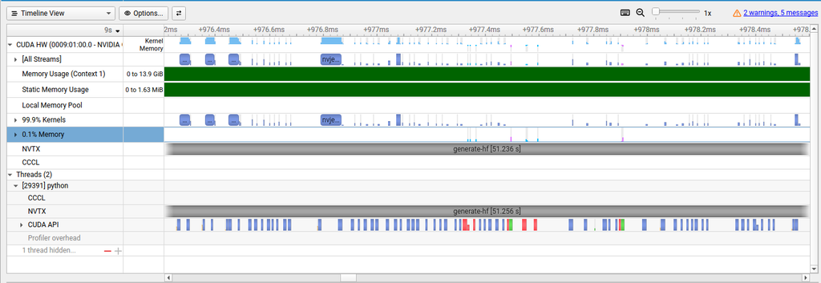

Transformers `generate()`: short bursts of GPU work, with gaps while Python launches the next kernel

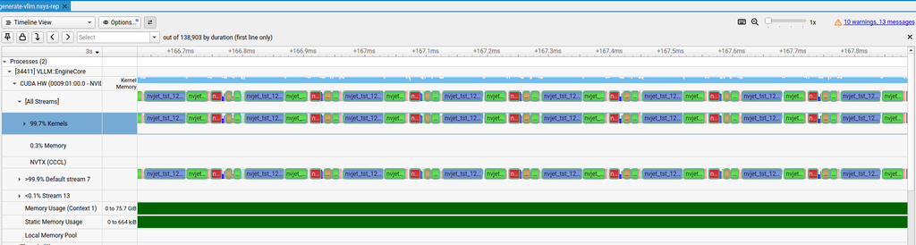

vLLM: kernels run back to back

**TipKey points**

- A profile records every GPU kernel; kernel time divided by elapsed time shows how busy the GPU was.
- A mostly idle GPU is usually waiting for the CPU, often for Python launching kernels one at a time.
- Measure, look at the profile, change one thing, and measure again.

**ImportantInstructor notes**

Not part of the 2-hour timings. If there is time at the end, demonstrate it with the supplied reports in `$PROJECTDIR/hpc-for-ai-2/data/fallback/reports`.

**NoteExercise (stretch goal): change one thing**

In the batched run, `_lora_expand_kernel` and `_lora_shrink_kernel` together took about a quarter of the kernel time, so the adapter itself has a visible cost. Is that worth paying? Pick one experiment, predict the result, then record it under a new name and compare:

- Pass `lora_request=None` to `run_checked`. How much faster is the base model, and do the labels get worse?
- Change `max_tokens` in `classify_settings` from 5 to 150. What happens to the time, given that `stop` usually ends answers early?

Then, using only `profile-summary.sh`, rank your reports by how busy the GPU was. Which would you try to improve first, and what would you change?

**CautionAnswer**

Your numbers will differ. Without the adapter, the LoRA kernels disappear from the profile and the batch gets faster, but compare the labels before deciding it’s worth it: the speed-up only matters if the answers are as good. With `max_tokens=150`, most answers still stop early at `###`, so the time should change much less than thirty-fold. The report with the least busy GPU is usually `generate-hf`: the fix there is the one vLLM already applies, batching and fewer kernel launches from Python.

## Credits and citation

The training settings come from the BriCS [Isambard-AI fine-tuning tutorial](https://docs.isambard.ac.uk/user-documentation/tutorials/llms/fine-tuning/). Data: [Stanford Alpaca](https://github.com/tatsu-lab/stanford_alpaca) (non-commercial use) and UK front-page headlines from [The Hear](https://www.thehear.org). Developed by the [Jean Golding Institute](https://www.bristol.ac.uk/golding/). Jean Golding Institute © CC BY 4.0.

The papers and sources cited in these notes:

- Dettmers et al. (2023). [QLoRA: Efficient Finetuning of Quantized LLMs](https://arxiv.org/abs/2305.14314).
- Hu et al. (2021). [LoRA: Low-Rank Adaptation of Large Language Models](https://arxiv.org/abs/2106.09685).
- Knuth (1974). [Structured Programming with go to Statements](https://doi.org/10.1145/356635.356640). *ACM Computing Surveys* 6(4).
- Lewis et al. (2020). [Retrieval-Augmented Generation for Knowledge-Intensive NLP Tasks](https://arxiv.org/abs/2005.11401).
- NVIDIA. [Making GPU Clusters More Efficient with NVIDIA Data Center Monitoring](https://developer.nvidia.com/blog/making-gpu-clusters-more-efficient-with-nvidia-data-center-monitoring/).
- Patterson et al. (2021). [Carbon Emissions and Large Neural Network Training](https://arxiv.org/abs/2104.10350).
- Şencan et al. (2025). [Analyzing GPU Utilization in HPC Workloads: Insights from Large-Scale Systems](https://www.bu.edu/cise/bu-ph-d-candidate-efe-sencan-and-team-win-best-paper-award-at-pearc-conference). PEARC.
- Strubell et al. (2019). [Energy and Policy Considerations for Deep Learning in NLP](https://arxiv.org/abs/1906.02243).
- [Green500](https://top500.org/lists/green500/list/2026/06/), June 2026.

# Instructor setup

**ImportantInstructor notes**

Everything in this section needs doing **before the course**. Allow at least a few weeks for getting access.

**1. The training project and interactive nodes**

The course runs in the training project, using the `interactive` reservation, with 1 GH200 per attendee. Check with BriCS whether the project has a GPU limit and whether its allocation covers 2-hour sessions for everyone, the instructors and the dry run. Send project invitations at least a week before, and remind people to set a UNIX username.

**2. Shared files**

Everything lives in one place: this repository, cloned into `$PROJECTDIR/hpc-for-ai-2`. The scripts in `setup/` fill its `data/` folder, which git ignores. Participants can read all of it but not change it.

```
$PROJECTDIR/hpc-for-ai-2/
├── notebooks/hpc-for-ai-2.ipynb    the notebook participants copy
├── setup/                          the scripts below, and profile-summary.sh
└── data/                           not in git
    ├── .venv/                      the course Python environment
    ├── kernels/                    the Fine-tuning + Nsight kernel and install-kernels.sh
    ├── hf-cache/                   Mistral 7B v0.3 and the Alpaca download (about 28 GB)
    ├── alpaca/train.parquet        Alpaca, saved for offline loading
    ├── headlines/                  uk_headlines.json
    └── fallback/                   lora/ and qlora/ trained adapters with stats.json, and reports/
```

**Warningdata/ is not in git**

`git clean -xdf`, or deleting and re-cloning the repository, deletes `data/` and everything in it. Update the course with `git pull`.

Do these in order, from the top of the repository, over SSH on a login node. Each job runs in the `interactive` reservation, which allows one job per person at a time, so submit each when the one before has finished. `setup/README.md` has the same steps as a checklist. Once the headlines file is in place, `bash setup/setup-all.sh` does steps 2, 4 and 5 in a single job.

1. **Clone the repository** and let the project read it:

   ```
   Terminal (login node)
   ```

   ```bash
   git clone https://github.com/Bristol-Training/hpc-for-ai-2.git $PROJECTDIR/hpc-for-ai-2
   cd $PROJECTDIR/hpc-for-ai-2
   chmod -R g+rX,g-w .
   ```

   Keep it on the branch you are teaching from: participants copy the notebook from it.
2. **Build the environment, model, dataset and kernel** (about 30 minutes). This builds the Python environment in `data/.venv`, downloads Mistral 7B and Alpaca into `data/hf-cache`, saves `data/alpaca/train.parquet`, checks it all loads offline, and writes the kernel and `install-kernels.sh` to `data/kernels`. It needs `uv` on your `PATH`.

   ```
   Terminal (login node)
   ```

   ```bash
   sbatch --reservation=interactive --nodes=1 --gpus=1 --time=01:00:00 \
          --output=setup-%j.out setup/build-environment.sh
   ```

3. **Add the headlines dataset:** put `uk_headlines.json` in `$PROJECTDIR/hpc-for-ai-2/data/headlines/` (see `setup/headlines/README.md` to rebuild it).
4. **Make the fallback adapters and supplied reports.** `setup/dry-run/dry-run.sbatch` runs the whole notebook as a participant would, on the course kernel, and records the six reports for section 10. With `publish`, it copies the run’s adapter, `stats.json` and reports into `data/fallback/`. Run it once in each mode (each takes about 15 minutes):

   ```
   Terminal (login node)
   ```

   ```bash
   sbatch --reservation=interactive setup/dry-run/dry-run.sbatch qlora publish
   sbatch --reservation=interactive setup/dry-run/dry-run.sbatch lora publish
   ```

   Re-run both whenever the training settings change, so the fallback matches the notebook.
5. **Permissions:** `chmod -R g+rX,g-w $PROJECTDIR/hpc-for-ai-2` again, so the project can read everything the jobs made. Participants’ own folders are `$PROJECTDIR/$USER`.

**3. Dry run (essential)**

Run the whole notebook in a JupyterHub session with 1 GH200, once in each mode, and check the points below. `setup/dry-run/dry-run.sbatch` without `publish` runs the same checks as a batch job; add `fallback` after the mode to test the fallback path.

- Training time: LoRA 8.0 min, QLoRA 8.8 min. Attaching Nsight costs a little: the same run took 7.6 min without it.
- Peak memory and final loss: LoRA 16.1 GiB, 0.903; QLoRA 5.8 GiB, 0.908.
- vLLM starts in a minute or two, and classifies all 29,823 headlines in under a minute.
- The fallback path (`USE_FALLBACK = True`) runs to the end.
- How long it takes to get a 1-GH200 session at the time of day the course will run.
- `$PROJECTDIR` points at the course project in a JupyterHub session, including for someone whose default project is a different one.
- Feedback form link (section 9).